# How Does Carbon Footprint Information Affect Consumer Choice? Power Analysis

### Example Analysis

Here we show for one run of the simulation what our main tests would look like in the paper. As we have very strong daily effects, we report the results by day for descriptive purposes.

```r
mp <- sim_meal_plan()
bs <- sim_base_sample(parms, mp)
df <- apply_teffects(bs, mp, tplan, eff_sizes)

kable(
  df %>%
    group_by(day) %>%
    summarise(
      diners = n(),
      meat_fish = mean(meat_fish),
      mn_weight = mean(food_weight),
      sd_weight = sd(food_weight),
      min_weight = min(food_weight),
      max_weight = max(food_weight),
      mn_co2e = mean(co2e),
      sd_co2e = sd(co2e),
      min_co2e = min(co2e),
      max_co2e = max(co2e)
    )
  ) %>% kable_styling()
```

| day | diners | meat_fish | mn_weight | sd_weight | min_weight | max_weight | mn_co2e | sd_co2e | min_co2e | max_co2e |
| --- | --- | --- | --- | --- | --- | --- | --- | --- | --- | --- |
| 1 | 2879 | 0.5679055 | 476.4293 | 140.3549 | 106.94436 | 1006.0236 | 4022.5820 | 2406.1706 | 291.91591 | 7539.306 |
| 2 | 3569 | 0.2810311 | 501.0191 | 154.1723 | 98.62007 | 1086.7409 | 712.1435 | 307.7471 | 109.15940 | 1582.508 |
| 3 | 3437 | 0.5528077 | 442.3066 | 132.3500 | 107.09163 | 951.3174 | 1034.8779 | 375.7967 | 195.21728 | 2103.872 |
| 4 | 3299 | 0.5074265 | 415.1640 | 130.9378 | 95.89109 | 908.1917 | 3275.8093 | 2883.1132 | 82.48093 | 6532.341 |
| 5 | 2576 | 0.3528727 | 480.7224 | 146.8392 | 96.42443 | 979.2972 | 987.4350 | 660.1788 | 103.57348 | 2367.226 |
| 6 | 3056 | 0.5274869 | 501.4371 | 156.5042 | 109.82832 | 1098.9873 | 1782.7014 | 1086.8321 | 143.90925 | 3462.472 |
| 7 | 3136 | 0.5892857 | 539.6248 | 149.6290 | 101.40889 | 1054.4222 | 1155.0448 | 434.7386 | 146.15702 | 2136.044 |
| 8 | 3326 | 0.5817799 | 486.3128 | 136.5029 | 93.49209 | 963.7239 | 4079.9311 | 2718.8409 | 255.39342 | 7246.497 |
| 9 | 3391 | 0.5387791 | 546.1320 | 161.6859 | 94.82859 | 1106.0237 | 2458.0055 | 1466.5592 | 156.15871 | 4714.297 |
| 10 | 2348 | 0.3884157 | 505.4143 | 151.9959 | 102.21165 | 1082.0723 | 1788.7186 | 713.4260 | 291.14436 | 4038.209 |

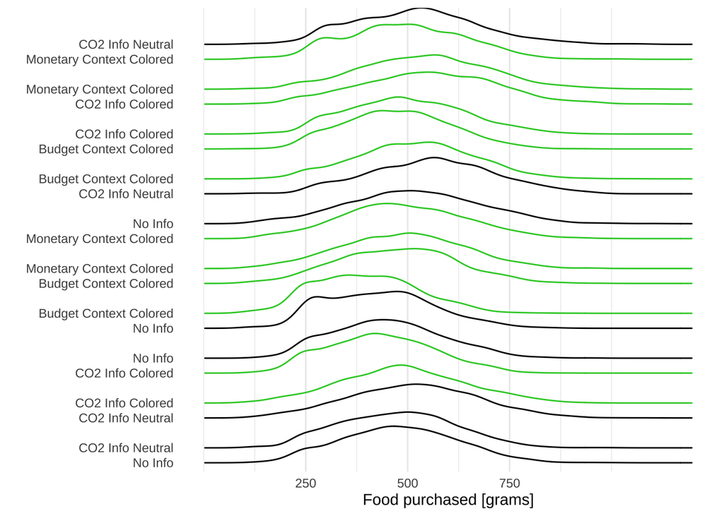

```r
df <- df %>%
  mutate(
    day = as.factor(day), slot = as.factor(slot)
  )

df_viz <- df %>%
  mutate(
    day_tment = factor(
      (as.numeric(day) - 1) * (parms$treatment_slots_per_day + 1) +
        as.numeric(slot),
      levels = 1:29
    ),
    color_cond = ifelse(str_detect(tment, "Colored"), "ColorCoded", "Neutral")
  )

ylabs <- NULL
for (i in 1:parms$days) {
  tments_str <- tplan$tment
  tments_str[tments_str == "NoInfo"] <- "No Info"
  tments_str[tments_str == "CO2Neutral"] <- "CO2 Info Neutral"
  tments_str[tments_str == "CO2Colored"] <- "CO2 Info Colored"
  tments_str[tments_str == "BudgetColored"] <- "Budget Context Colored"
  tments_str[tments_str == "MoneyColored"] <- "Monetary Context Colored"
  row_start <- (i - 1)*parms$treatment_slots_per_day + 1
  row_end <- i*parms$treatment_slots_per_day
  ylabs <- c(ylabs, tments_str[row_start:row_end])
  if (i < parms$days) ylabs <- c(ylabs, "")
}

fig <- ggplot(df_viz, aes(x = food_weight, color = color_cond, y = day_tment)) +
  geom_density_ridges(fill = NA) +
  labs(y = "", x = "Food purchased [grams]") +
  scale_y_discrete(labels = ylabs, drop = FALSE) +
  scale_x_continuous(breaks = c(250, 500, 750))

style_ridges_plot(fig)
```

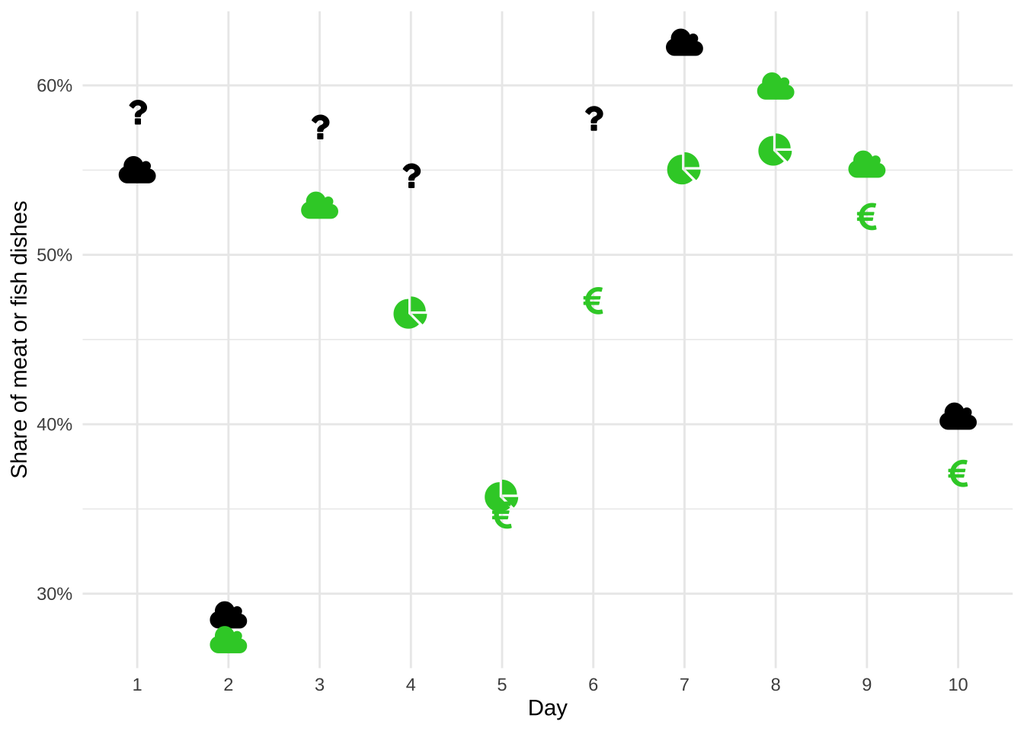

```r
save_plot("../output/figure_2_food_weight", 8, 6)


df_viz2 <- df_viz %>%
  group_by(day, tment, color_cond) %>%
  summarise(
    meat_fish = mean(meat_fish),
    .groups = "drop"
  ) %>%
  mutate(
    label = case_when(
      tment == "NoInfo" ~  fontawesome("fa-question"),
      tment == "CO2Neutral" ~ fontawesome("fa-cloud"),
      tment == "CO2Colored" ~ fontawesome("fa-cloud"),
      tment == "BudgetColored" ~ fontawesome("fa-pie-chart"),
      tment == "MoneyColored" ~ fontawesome("fa-eur")
    ),
    nudge_left = case_when(
      day == 1 & tment == "NoContext" ~ TRUE,
      TRUE ~ FALSE
    ),
    nudge_right = case_when(
      day == 1 & tment == "NoContext" ~ TRUE,
      TRUE ~ FALSE
    )
  )

ggplot() +
  geom_text(
    data = df_viz2 %>% filter(!nudge_left & !nudge_right),
    aes(x = day, y = meat_fish, color = color_cond, label = label),
    family='fontawesome-webfont', size = 6
  ) +
  geom_text(
    data = df_viz2 %>% filter(nudge_left),
    aes(x = day, y = meat_fish, color = color_cond, label = label),
    family='fontawesome-webfont', size = 6,
    position = position_nudge(x = -0.15)
  ) +
  geom_text(
    data = df_viz2 %>% filter(nudge_right),
    aes(x = day, y = meat_fish, color = color_cond, label = label),
    family='fontawesome-webfont', size = 6,
    position = position_nudge(x = +0.15)
  ) +
  scale_color_manual(
    values = c("ColorCoded" = "limegreen", "Neutral" = "black"),
    guide = "none"
  ) +
  scale_y_continuous(labels = scales::label_percent(accuracy = 1L)) +
  labs(x = "Day", y = "Share of meat or fish dishes") +
  theme_minimal()
```

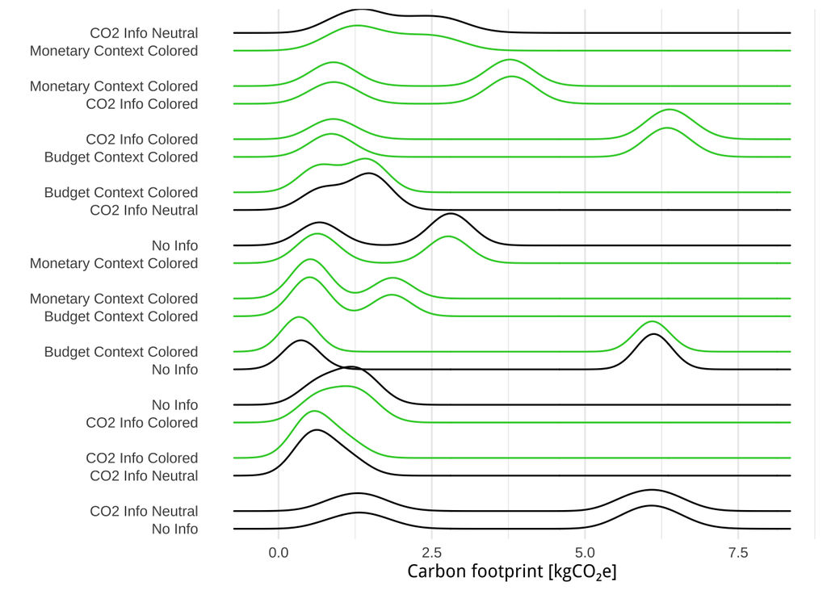

```r
save_plot("../output/figure_3_food_choice", 6, 6)

fig <- ggplot(df_viz, aes(x = co2e/1000, color = color_cond, y = day_tment)) +
  geom_density_ridges(fill = NA) +
  labs(y = "", x = "Carbon footprint [kgCO\u2082e]") +
  scale_y_discrete(labels = ylabs, drop = FALSE) +
  scale_x_continuous(breaks = c(0, 2.5, 5.0, 7.5))

style_ridges_plot(fig)
```

```r
save_plot("../output/figure_4_food_co2e", 8, 6)


weight_mod <- feols(
  log(food_weight) ~ tment| day + slot,
  df, cluster = c("dayslot")
)
mtfsh_mod <- femlm(
  meat_fish ~ tment| day + slot,
  family = "logit", df, cluster = c("dayslot")
)
mtfsh_mod_ols <- feols(
  meat_fish ~ tment| day + slot,
  df, cluster = c("dayslot")
)
co2e_mod <- feols(
  log(co2e) ~ tment| day + slot,
  df, cluster = c("dayslot")
)


modelsummary(
  list(
    weight = weight_mod, meat_fish_logit = mtfsh_mod, co2e = co2e_mod
  ),
  stars = TRUE
)
```

|  | weight | meat_fish_logit | co2e |
| --- | --- | --- | --- |
| tmentCO2Neutral | −0.004 | −0.137*** | −0.088*** |
|  | (0.003) | (0.020) | (0.016) |
| tmentCO2Colored | −0.044*** | −0.215*** | −0.114*** |
|  | (0.002) | (0.015) | (0.016) |
| tmentBudgetColored | −0.081*** | −0.367*** | −0.221*** |
|  | (0.002) | (0.021) | (0.018) |
| tmentMoneyColored | −0.055*** | −0.370*** | −0.183*** |
|  | (0.002) | (0.026) | (0.014) |
| Num.Obs. | 31017 | 31017 | 31017 |
| R2 | 0.064 |  | 0.274 |
| R2 Adj. | 0.064 |  | 0.273 |
| R2 Within | 0.006 |  | 0.006 |
| R2 Pseudo |  | 0.034 |  |
| AIC | 18789.6 | 41568.9 | 74443.3 |
| BIC | 18914.8 | 41694.0 | 74568.5 |
| Log.Lik. | −9379.822 | −20769.435 | −37206.671 |
| Std.Errors | by: dayslot | by: dayslot | by: dayslot |
| FE: day | X | X | X |
| FE: slot | X | X | X |

+ p < 0.1, * p < 0.05, ** p < 0.01, *** p < 0.001

```r
test_hypothesis <- function(mod, test) {
  rv <- car::linearHypothesis(mod, test)
  tibble(
    effect = unname(attr(rv, "value")[1,1]),
    pvalue = rv[2, 4],
    starred = sprintf(
      "%.3f%s", effect,
      case_when(
        pvalue < 0.01 ~ "***",
        pvalue < 0.05 ~ "**",
        pvalue < 0.1 ~ "*",
        TRUE ~ ""
      )
    )
  )
}

construct_lin_hypothesis <- function(df) {
  no_info <- tments[1]
  weights <- pull(
    df %>% filter(tment != no_info) %>% group_by(tment) %>%
      summarise(share = n()/nrow(df))
  )


  h1_test <- paste0(
    paste0(
      weights/sum(weights), " * tment", tments[-1], collapse = " + "
    ),
    " = 0"
  )

  h2_test <- paste0(
    "-tment", tments[3], " + ",
    paste0(
      weights[3:4]/sum(weights[3:4]), " * tment", tments[4:5],
      collapse = " + "
    ),
    " = 0"
  )

  h3_test <- paste0("tment", tments[4], " -tment", tments[5], " = 0")

  h4_test <- paste0("tment", tments[3], " -tment", tments[2], " = 0")

  return(c(
    h1 = h1_test,
    h2 = h2_test,
    h3 = h3_test,
    h4 = h4_test
  ))
}

lh <- construct_lin_hypothesis(df)

hresults <- matrix(NA_character_, 4, 3)

col <- 0
for (mod in list(weight_mod, mtfsh_mod, co2e_mod)) {
  col <- col + 1
  hresults[1, col] <- test_hypothesis(mod, lh["h1"])$starred
  hresults[2, col] <- test_hypothesis(mod, lh["h2"])$starred
  hresults[3, col] <- test_hypothesis(mod, lh["h3"])$starred
  hresults[4, col] <- test_hypothesis(mod, lh["h4"])$starred
}
rownames(hresults) <- c("H1", "H2", "H3", "H4")
colnames(hresults) <- c("weight_mod", "mtfsh_mod", "co2e_mod")

kable(hresults) %>% kable_styling()
```

|  | weight_mod | mtfsh_mod | co2e_mod |
| --- | --- | --- | --- |
| H1 | -0.046*** | -0.269*** | -0.150*** |
| H2 | -0.025*** | -0.154*** | -0.088*** |
| H3 | -0.026*** | 0.003 | -0.039*** |
| H4 | -0.040*** | -0.078*** | -0.026** |

```r
# Save all results for slide deck

save(
  parms, mp, bs, df, weight_mod, mtfsh_mod, co2e_mod, hresults,
  file = "../output/pa_example_run.rdata"
)
```

### Calculating Power

Now we estimate the power for our hypotheses tests by

- simulating a base sample,
- applying treatment effects,
- running the analysis on the treated sample,
- performing our hypothesis tests,
- capturing the effects and the confidence intervals,
- verifying whether they are significantly different from zero,
- repeating this procedure a given number of times and
- reporting the share of hypothesis tests that are significant.

```r
test_hypotheses <- function(df, level) {
  weight_mod <- feols(
    log(food_weight) ~ tment| day + slot,
    cluster = c("dayslot"), df
  )
  mtfsh_mod <- femlm(
    meat_fish ~ tment| day + slot, family = "logit",
    cluster = c("dayslot"), df
  )
  co2e_mod <- feols(
    log(co2e) ~ tment| day + slot,
    cluster = c("dayslot"), df
  )

  bind_cols(
    expand_grid(
      mod = c("weight", "mtfsh", "co2e"),
      test = c("h1", "h2", "h3", "h4")
    ),
    bind_rows(lapply(
    list(weight_mod, mtfsh_mod, co2e_mod),
    function(mod) {
      bind_rows(lapply(
        construct_lin_hypothesis(df),
        function(test) test_hypothesis(mod, test)
      ))
    }
    ))
  )
}

run_sim <- function(p, tp, te) {
  mp <- sim_meal_plan()
  bs <- sim_base_sample(p, mp)
  df <- apply_teffects(bs, mp, tp, te)
  test_hypotheses(df)
}

if (file.exists("../data/generated/power_runs.rds")) {
  df <- readRDS("../data/generated/power_runs.rds")
} else {
  df <- do.call(
    rbind,
    replicate(1000, run_sim(parms, tplan, eff_sizes), simplify = FALSE)
  )
  saveRDS(df, "../data/generated/power_runs.rds")
}

sim_results <-  df %>% group_by(mod, test) %>%
  filter(!is.na(pvalue) & pvalue != 1) %>%
  summarise(
    n = n(),
    mn_effect = mean(effect),
    sd_effect = sd(effect),
    pct_sig_neg = mean(pvalue < 0.05 & effect < 0),
    pct_sig_pos = mean(pvalue < 0.05 & effect > 0),
    .groups = "drop"
  ) %>%
  pivot_wider(
    id_cols = test, names_from = mod,
    values_from = c(n, mn_effect, sd_effect, pct_sig_pos, pct_sig_neg),
    names_glue = "{mod}_{.value}"
  ) %>%
  select(test, starts_with("weight"), starts_with("mtfsh"), starts_with("co2e"))

kable(sim_results) %>% kable_styling()
```

| test | weight_n | weight_mn_effect | weight_sd_effect | weight_pct_sig_pos | weight_pct_sig_neg | mtfsh_n | mtfsh_mn_effect | mtfsh_sd_effect | mtfsh_pct_sig_pos | mtfsh_pct_sig_neg | co2e_n | co2e_mn_effect | co2e_sd_effect | co2e_pct_sig_pos | co2e_pct_sig_neg |
| --- | --- | --- | --- | --- | --- | --- | --- | --- | --- | --- | --- | --- | --- | --- | --- |
| h1 | 1000 | -0.0514426 | 0.0060616 | 0 | 1.000 | 1000 | -0.2092196 | 0.0369016 | 0.000 | 1.000 | 1000 | -0.1095096 | 0.0239763 | 0.000 | 1.000 |
| h2 | 1000 | -0.0320557 | 0.0064564 | 0 | 1.000 | 1000 | -0.1289235 | 0.0396448 | 0.000 | 0.987 | 1000 | -0.0686483 | 0.0219420 | 0.000 | 0.978 |
| h3 | 1000 | -0.0217050 | 0.0078273 | 0 | 0.941 | 1000 | -0.0858050 | 0.0489985 | 0.005 | 0.754 | 1000 | -0.0459130 | 0.0282292 | 0.006 | 0.766 |
| h4 | 1000 | -0.0210958 | 0.0077418 | 0 | 0.942 | 1000 | -0.0865003 | 0.0461692 | 0.003 | 0.793 | 1000 | -0.0455450 | 0.0235225 | 0.000 | 0.816 |

### Power by Effect Size

How does the power of a single treatment vary relative to its (differential) effect size?

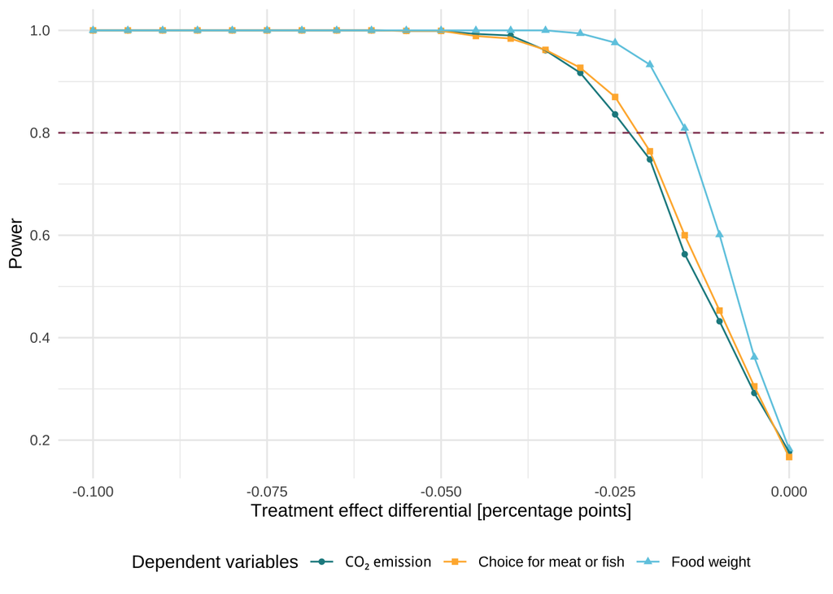

```r
test_diff <- function(p, tp, te) {
  mp <- sim_meal_plan()
  bs <- sim_base_sample(p, mp)
  df <- apply_teffects(bs, mp, tp, te) %>%
    mutate(dayslot = factor(day*10 + slot))

  weight_mod <- feols(
    log(food_weight) ~ tment| day + slot,
    cluster = c("dayslot"), df
  )
  mtfsh_mod <- femlm(
    meat_fish ~ tment| day + slot, family = "logit",
    cluster = c("dayslot"), df
  )
  co2e_mod <- feols(
    log(co2e) ~ tment| day + slot,
    cluster = c("dayslot"), df
  )

  diff_test <- "tmentCO2Neutral = 0"

  bind_cols(
    mod = c("weight", "mtfsh", "co2e"),
    bind_rows(lapply(
      list(weight_mod, mtfsh_mod, co2e_mod),
      function(mod) {
        test_hypothesis(mod, diff_test)
      }
    ))
  )
}

if (file.exists("../data/generated/power_differential_effects.rds")) {
  df <- readRDS("../data/generated/power_differential_effects.rds")
} else {
  prot <- expand_grid(
    run = 1:1000,
    diff_effect = seq(-0.0, -0.10, length.out = 21)
  )

  run_protocol <- function(n) {
    df <- prot[n, ]
    te <- eff_sizes
    te[te$tment == "CO2Neutral", "mn_weight"] <- df$diff_effect
    te[te$tment == "CO2Neutral", "mn_mtfsh"] <- df$diff_effect
    message(sprintf(
      "Running run %d with parameter %.3f", df$run, df$diff_effect
    ))
    bind_cols(df, test_diff(parms, tplan, te))
  }

  df <- bind_rows(
    lapply(1:nrow(prot), run_protocol)
  )

  saveRDS(df, "../data/generated/power_differential_effects.rds")
}

df %>%
  group_by(mod, diff_effect) %>%
  summarise(
    alpha = mean(effect < 0 & pvalue < 0.05),
    .groups = "drop"
  ) %>%
  ggplot(aes(x = diff_effect, y = alpha, color = mod, shape = mod)) +
  geom_point() +
  geom_line() +
  labs(y = "Power", x = "Treatment effect differential [percentage points]")+
  scale_y_continuous(breaks = seq(0, 1, by = 0.2)) +
    geom_hline(yintercept = 0.8, color = col_trr266_red, lty = 2) +
    scale_shape_manual(
      values = c("co2e" = 16, "mtfsh" = 15, "weight" = 17),
      name = "Dependent variables",
      labels = c("CO\u2082 emission", "Choice for meat or fish", "Food weight")
      ) +
    scale_color_manual(
      values = c("co2e" = col_trr266_petrol, "mtfsh" = col_trr266_yellow, "weight" = col_trr266_blue),
      name = "Dependent variables",
      labels = c("CO\u2082 emission", "Choice for meat or fish", "Food weight")
      )+
    theme_minimal() +
    theme(
      legend.position = "bottom"
    )
```

```r
save_plot("../output/figure_5_power", 6, 6)
```